# Usando Regressão Linear para Explicar a votação de Deputados

Nessa análise, estamos interessados em responder algumas perguntas sobre os dados sobre as votações para Deputados Federais nos anos de 2006 e 2010.  
Esses dados foram retirados da página do TSE (Tribunal Superior Eleitoral).

```r
# função que recebe uma variável categórica e a tranforma em uma numérica
dummyfy <- function (variable) {
  return (
    variable %>%
    as.factor %>%
    as.numeric
  )
}
```

## Pergunta 1: Um modelo de regressão múltipla com todas as variáveis é plausível para explicar a variação em y (número de votos) em 2006? Mesma pergunta para 2010.

Para responder essa pergunta, precisamos criar um modelo de regressão linear em que o número de votos está em função de todas as variáveis do conjunto de dados. Contudo, podemos observar que temos algumas variáveis categóricas, e que não podem ser simplismente utilizadas no modelo de regressão. Assim, ficamos com duas alternativas:  
1. Descartar essas variáveis  
2. Utilizar alguma estratégia para converter as variáveis categóricas em numéricas.

Como podemos ter informações importantes para explicar o número de votos nas variáveis categóricas, decidimos ir pelo caminho da 2a alternativa. Para implementar isso, utilizamos a estratégia de dummyficação, onde é atribuído um valor numérico gerado a partir de um valor categórico. Para tal, utilizamos as funções *as.factor* e *as.numeric*.

Além disso, geramos um novo conjunto de dados contendo só as variáveis numéricas do conjunto dados original e as variáveis dummyficadas para que possamos utilizar no model de regressão linear.

Ao fim, geramos o modelo e sumarizamos suas informações.

### Para 2006

```r
#importa dados
dados2006_2010 <- readr::read_csv(
  here::here('dados/eleicoes_2006_e_2010.csv'),
  local=readr::locale("br"),
  col_types = cols(
    ano = col_integer(),
    sequencial_candidato = col_character(),
    quantidade_doacoes = col_integer(),
    quantidade_doadores = col_integer(),
    total_receita = col_double(),
    media_receita = col_double(),
    recursos_de_outros_candidatos.comites = col_double(),
    recursos_de_pessoas_fisicas = col_double(),
    recursos_de_pessoas_juridicas = col_double(),
    recursos_proprios = col_double(),
    `recursos_de_partido_politico` = col_double(),
    quantidade_despesas = col_integer(),
    quantidade_fornecedores = col_integer(),
    total_despesa = col_double(),
    media_despesa = col_double(),
    votos = col_integer(),
    .default = col_character()))


dados2006 <- dados2006_2010 %>% filter(ano == 2006)

# dummyfica variáveis categóricas
dados2006$sequencial_candidato.dummy <- dummyfy(dados2006$sequencial_candidato)
dados2006$nome.dummy <- dummyfy(dados2006$nome)
dados2006$uf.dummy <- dummyfy(dados2006$uf)
dados2006$partido.dummy <- dummyfy(dados2006$partido)
dados2006$cargo.dummy <- dummyfy(dados2006$cargo)
dados2006$sexo.dummy <- dummyfy(dados2006$sexo)
dados2006$grau.dummy <- dummyfy(dados2006$grau)
dados2006$estado_civil.dummy <- dummyfy(dados2006$estado_civil)
dados2006$ocupacao.dummmy <- dummyfy(dados2006$ocupacao)

# remove variáveis que foram dummyficadas
dadosRegressao2006 <-
  dados2006 %>%
  select(-sequencial_candidato, -nome, -uf, -partido, -cargo, -sexo, -grau, -estado_civil, -ocupacao)

modeloCandidatos2006 <- lm(formula = votos ~ ., dadosRegressao2006, na.action = na.omit)

summary(modeloCandidatos2006)
```

```
##
## Call:
## lm(formula = votos ~ ., data = dadosRegressao2006, na.action = na.omit)
##
## Residuals:
##     Min      1Q  Median      3Q     Max
## -227959   -8104   -4039     721  642101
##
## Coefficients: (3 not defined because of singularities)
##                                         Estimate Std. Error t value
## (Intercept)                            1.474e+03  4.508e+03   0.327
## ano                                           NA         NA      NA
## quantidade_doacoes                    -7.560e+01  1.240e+02  -0.609
## quantidade_doadores                    3.425e+02  1.340e+02   2.555
## total_receita                         -1.034e-01  2.186e-02  -4.730
## media_receita                          1.156e+00  1.050e-01  11.015
## recursos_de_outros_candidatos.comites  4.011e-02  2.351e-02   1.706
## recursos_de_pessoas_fisicas            1.574e-01  2.233e-02   7.050
## recursos_de_pessoas_juridicas          7.352e-02  1.821e-02   4.037
## recursos_proprios                      9.829e-03  1.871e-02   0.525
## recursos_de_partido_politico                  NA         NA      NA
## quantidade_despesas                   -2.206e+01  9.798e+00  -2.251
## quantidade_fornecedores               -5.705e+00  1.301e+01  -0.439
## total_despesa                          1.351e-01  1.303e-02  10.366
## media_despesa                          8.021e-01  4.192e-01   1.914
## sequencial_candidato.dummy            -1.534e+00  1.210e+00  -1.267
## nome.dummy                            -5.007e-01  5.461e-01  -0.917
## uf.dummy                              -5.137e+01  7.724e+01  -0.665
## partido.dummy                         -1.096e+02  6.884e+01  -1.592
## cargo.dummy                                   NA         NA      NA
## sexo.dummy                             3.215e+03  1.688e+03   1.904
## grau.dummy                             8.102e+02  3.217e+02   2.519
## estado_civil.dummy                    -4.464e+02  4.452e+02  -1.003
## ocupacao.dummmy                       -3.342e+01  1.327e+01  -2.518
##                                       Pr(>|t|)
## (Intercept)                             0.7437
## ano                                         NA
## quantidade_doacoes                      0.5423
## quantidade_doadores                     0.0107 *
## total_receita                         2.34e-06 ***
```

[output cut: 10 more lines]

```
## sequencial_candidato.dummy              0.2052
## nome.dummy                              0.3593
## uf.dummy                                0.5060
## partido.dummy                           0.1116
## cargo.dummy                                 NA
## sexo.dummy                              0.0569 .
## grau.dummy                              0.0118 *
## estado_civil.dummy                      0.3160
## ocupacao.dummmy                         0.0118 *
## ---
## Signif. codes:  0 '***' 0.001 '**' 0.01 '*' 0.05 '.' 0.1 ' ' 1
##
## Residual standard error: 31560 on 3415 degrees of freedom
## Multiple R-squared:  0.521,  Adjusted R-squared:  0.5182
## F-statistic: 185.8 on 20 and 3415 DF,  p-value: < 2.2e-16
```

Podemos ver que o modelo é plausível sim.

A partir do **p-valor**, podemos ver que a probabilidade do modelo ser igual ou pior que a hipótese nula é extremamente baixa. Além disso, obeservando o valor do **R-quadrado ajustado** podemos ver que todas as variáveis em conjuto explicam aproximadamente **52%** dos valores de votos observados.

### Para 2010

Faremos os precedimentos de forma análoga a 2006

```r
dados2010 <- dados2006_2010 %>% filter(ano == 2010)

# dummyfica variáveis categóricas
dados2010$sequencial_candidato.dummy <- dummyfy(dados2010$sequencial_candidato)
dados2010$nome.dummy <- dummyfy(dados2010$nome)
dados2010$uf.dummy <- dummyfy(dados2010$uf)
dados2010$partido.dummy <- dummyfy(dados2010$partido)
dados2010$cargo.dummy <- dummyfy(dados2010$cargo)
dados2010$sexo.dummy <- dummyfy(dados2010$sexo)
dados2010$grau.dummy <- dummyfy(dados2010$grau)
dados2010$estado_civil.dummy <- dummyfy(dados2010$estado_civil)
dados2010$ocupacao.dummmy <- dummyfy(dados2010$ocupacao)

# remove variáveis que foram dummyficadas
dadosRegressao2010 <-
  dados2010 %>%
  select(-sequencial_candidato, -nome, -uf, -partido, -cargo, -sexo, -grau, -estado_civil, -ocupacao)

modeloCandidatos2010 <- lm(formula = votos ~ ., dadosRegressao2010, na.action = na.omit)

summary(modeloCandidatos2010)
```

```
##
## Call:
## lm(formula = votos ~ ., data = dadosRegressao2010, na.action = na.omit)
##
## Residuals:
##     Min      1Q  Median      3Q     Max
## -213253   -9803   -5585    -471 1300402
##
## Coefficients: (3 not defined because of singularities)
##                                         Estimate Std. Error t value
## (Intercept)                            1.344e+04  4.498e+03   2.989
## ano                                           NA         NA      NA
## quantidade_doacoes                     2.643e+01  5.417e+01   0.488
## quantidade_doadores                   -8.722e+00  6.283e+01  -0.139
## total_receita                         -6.823e-03  9.498e-03  -0.718
## media_receita                         -2.112e-01  5.411e-02  -3.904
## recursos_de_outros_candidatos.comites  4.693e-03  6.087e-03   0.771
## recursos_de_pessoas_fisicas            4.511e-02  1.003e-02   4.499
## recursos_de_pessoas_juridicas         -5.370e-03  5.559e-03  -0.966
## recursos_proprios                     -3.111e-02  4.981e-03  -6.246
## recursos_de_partido_politico                  NA         NA      NA
## quantidade_despesas                    1.403e+01  9.113e+00   1.539
## quantidade_fornecedores               -3.146e+01  1.112e+01  -2.828
## total_despesa                          8.503e-02  9.986e-03   8.515
## media_despesa                          1.642e-01  8.962e-02   1.832
## sequencial_candidato.dummy             5.906e-01  5.109e-01   1.156
## nome.dummy                            -8.377e-01  5.036e-01  -1.663
## uf.dummy                              -2.052e+02  8.077e+01  -2.540
## partido.dummy                         -2.282e+02  7.702e+01  -2.963
## cargo.dummy                                   NA         NA      NA
## sexo.dummy                             2.109e+03  1.632e+03   1.292
## grau.dummy                             9.578e+02  3.388e+02   2.827
## estado_civil.dummy                    -1.304e+03  4.604e+02  -2.833
## ocupacao.dummmy                       -4.996e+01  1.362e+01  -3.668
##                                       Pr(>|t|)
## (Intercept)                           0.002820 **
## ano                                         NA
## quantidade_doacoes                    0.625658
## quantidade_doadores                   0.889594
## total_receita                         0.472561
```

[output cut: 10 more lines]

```
## sequencial_candidato.dummy            0.247708
## nome.dummy                            0.096318 .
## uf.dummy                              0.011120 *
## partido.dummy                         0.003061 **
## cargo.dummy                                 NA
## sexo.dummy                            0.196319
## grau.dummy                            0.004725 **
## estado_civil.dummy                    0.004629 **
## ocupacao.dummmy                       0.000248 ***
## ---
## Signif. codes:  0 '***' 0.001 '**' 0.01 '*' 0.05 '.' 0.1 ' ' 1
##
## Residual standard error: 37110 on 4019 degrees of freedom
## Multiple R-squared:  0.442,  Adjusted R-squared:  0.4393
## F-statistic: 159.2 on 20 and 4019 DF,  p-value: < 2.2e-16
```

Para 2010 vemos que o modelo também é plausível.

Temos um **p-valor** muito baixo e um **R-quadrado ajustado** indicando que o modelo explica cerca de **44%** dos valores de votos observados.

## Pergunta 2: Compare as regressões construídas para 2006 e 2010. Quais as diferenças/semelhanças percebidas?

Primeiramente vamos analisar o plot de **Valores Previstos vs Resíduos**, ele nos dará boas pistas sobre a qualidade de cada modelo e assim podemos entender algumas diferenças entre o de 2006 e o de 2010.

#### Valores Previstos X Resíduos

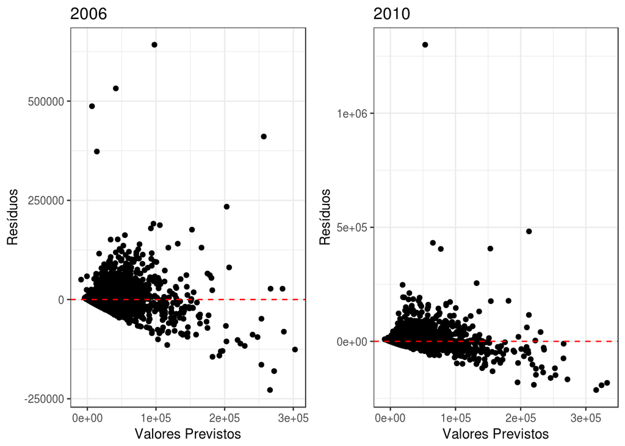

Em ambos os casos vemos que se formos quantificar a simetria dos pontos em relação á reta que cruza o y=0, seria um valor mediano, onde o modelo para 2006 se sairia levemente melhor. Indicando que este é também um pouco melhor em prever o número de votos de um candidato.

Isso confirma os valores que observamos de **R-quadrado ajustado** e **RSE** na questão anterior para os anos de 2006 e 2010, tendo o modelo de 2006 ligeiramente mais preciso que o de 2010.

## Pergunta 3: Todas as variáveis são úteis para os modelos de regressão? Há variáveis redudantes? Faça análises para 2006 e 2010 separadamente.

Para verificar se de fato todas as variáveis contribuem significativamente para o modelo, vamos observar a correlação entre elas, dessa forma, se duas ou mais variáveis possuirem um alto coeficiente de correlação entre si, isso significa que apenas uma delas está sendo relevante para o modelo.

#### Correlograma para 2006

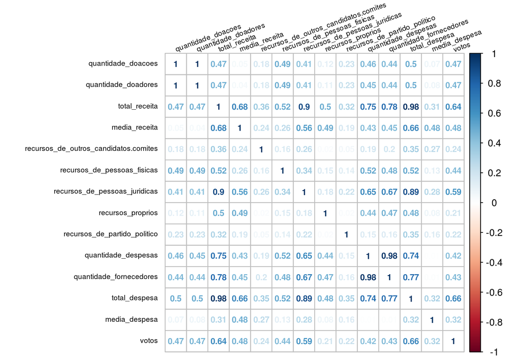

```r
dadosRegressao2006 %>%
  select(-ano, -sequencial_candidato.dummy, -nome.dummy, -uf.dummy, -partido.dummy, -cargo.dummy, -sexo.dummy, -grau.dummy, -estado_civil.dummy, -ocupacao.dummmy) %>%
  cor() %>%
  corrplot(
    method = "number",
    type = "full",
    tl.srt = 20,
    tl.col = "black",
    tl.cex = 0.6,
    tl.offset = 0.5,
    number.cex = 0.70,
    na.label = "NA"
  )
```

#### Correlograma para 2010

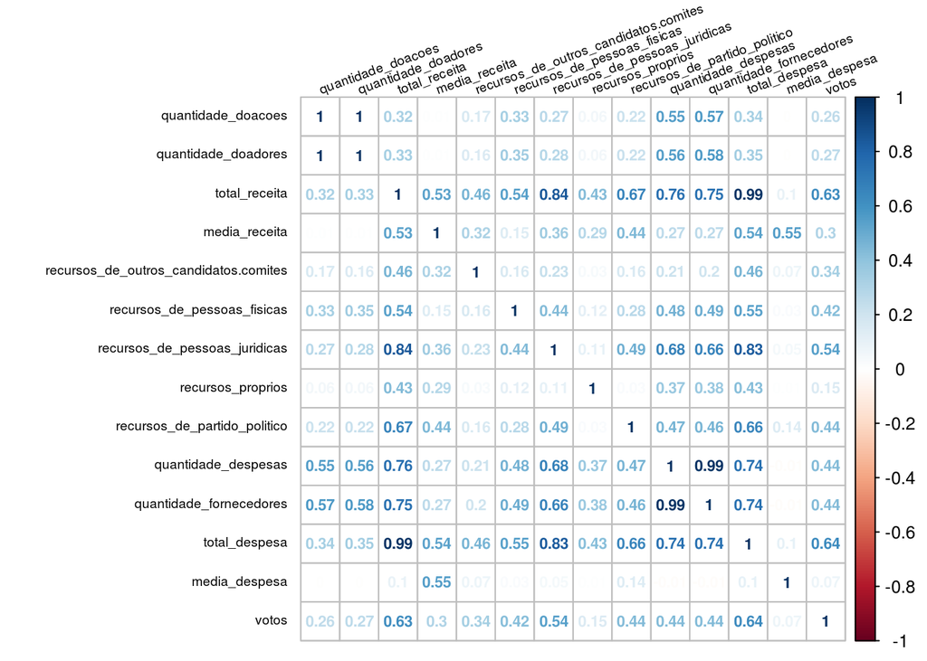

```r
dadosRegressao2010 %>%
  select(-ano, -sequencial_candidato.dummy, -nome.dummy, -uf.dummy, -partido.dummy, -cargo.dummy, -sexo.dummy, -grau.dummy, -estado_civil.dummy, -ocupacao.dummmy) %>%
  cor() %>%
  corrplot(
    method = "number",
    type = "full",
    tl.srt = 20,
    tl.col = "black",
    tl.cex = 0.6,
    tl.offset = 0.5,
    number.cex = 0.70,
    na.label = "NA"
  )
```

Podemos observar que em ambos os modelos (2006 e 2010) temos variáveis com um coeficiente de correlacão linear bem alto, o que é um bom indício que podemos cortar algumas variáveis do nosso modelo.

## Pergunta 4: No caso de haver variáveis pouco explicativas e/ou redudantes, construa um novo modelo sem essas variáveis e o compare ao modelo com todas as variáveis (e.g. em termos de R2 e RSE). Faça isso para 2006 e 2010 separadamente.

#### Para 2006:

A ideia aqui foi verificar coeficientes de correlação acima de 0.6 ou abaixo de -0.6 e eliminar uma das variáveis do modelo.

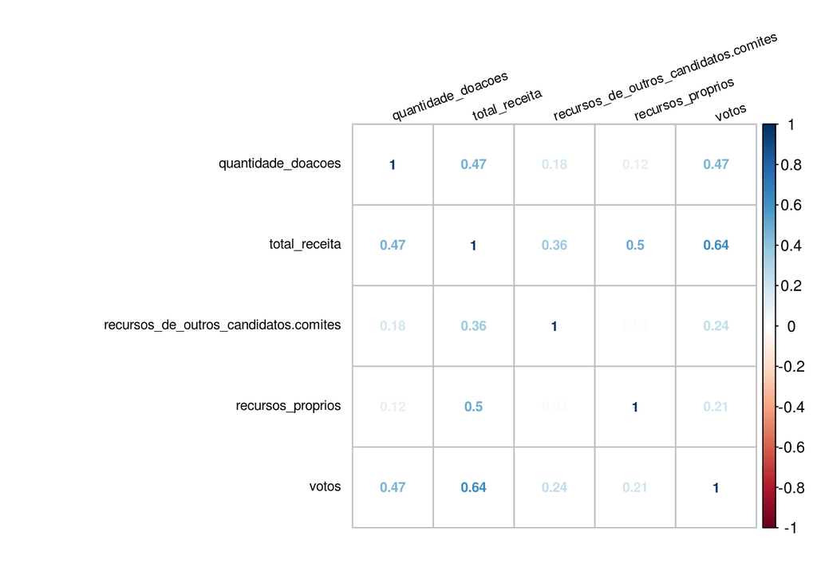

```r
dadosAjustados2006 <- dadosRegressao2006 %>%
  select(- quantidade_doadores, - recursos_de_pessoas_juridicas, - quantidade_despesas, -quantidade_fornecedores, - total_despesa, -recursos_de_partido_politico, - media_despesa, -media_receita, - recursos_de_pessoas_fisicas, recursos_de_outros_candidatos.comites) %>%
  select(-ano, -sequencial_candidato.dummy, -nome.dummy, -uf.dummy, -partido.dummy, -cargo.dummy, -sexo.dummy, -grau.dummy, -estado_civil.dummy, -ocupacao.dummmy)

dadosAjustados2006 %>%
  cor() %>%
  corrplot(
    method = "number",
    type = "full",
    tl.srt = 20,
    tl.col = "black",
    tl.cex = 0.7,
    tl.offset = 0.5,
    number.cex = 0.70,
    na.label = "NA"
  )
```

Ficamos então com o seguinte modelo:

```r
modeloAjustado2006 <- lm(formula = votos ~ ., dadosAjustados2006, na.action = na.omit)

summary(modeloAjustado2006)
```

```
##
## Call:
## lm(formula = votos ~ ., data = dadosAjustados2006, na.action = na.omit)
##
## Residuals:
##     Min      1Q  Median      3Q     Max
## -231994   -8692   -7472   -1497  641643
##
## Coefficients:
##                                         Estimate Std. Error t value
## (Intercept)                            8.046e+03  6.593e+02  12.203
## quantidade_doacoes                     1.951e+02  1.475e+01  13.224
## total_receita                          1.021e-01  3.023e-03  33.763
## recursos_de_outros_candidatos.comites -1.316e-02  1.786e-02  -0.737
## recursos_proprios                     -5.969e-02  7.531e-03  -7.927
##                                       Pr(>|t|)
## (Intercept)                            < 2e-16 ***
## quantidade_doacoes                     < 2e-16 ***
## total_receita                          < 2e-16 ***
## recursos_de_outros_candidatos.comites    0.461
## recursos_proprios                     3.02e-15 ***
## ---
## Signif. codes:  0 '***' 0.001 '**' 0.01 '*' 0.05 '.' 0.1 ' ' 1
##
## Residual standard error: 33790 on 3431 degrees of freedom
## Multiple R-squared:  0.4485, Adjusted R-squared:  0.4478
## F-statistic: 697.5 on 4 and 3431 DF,  p-value: < 2.2e-16
```

Conseguimos enxugar bastante o modelo sem perder muito do que ele explica.

#### Para 2010

Faremos de forma análoga para 2010:

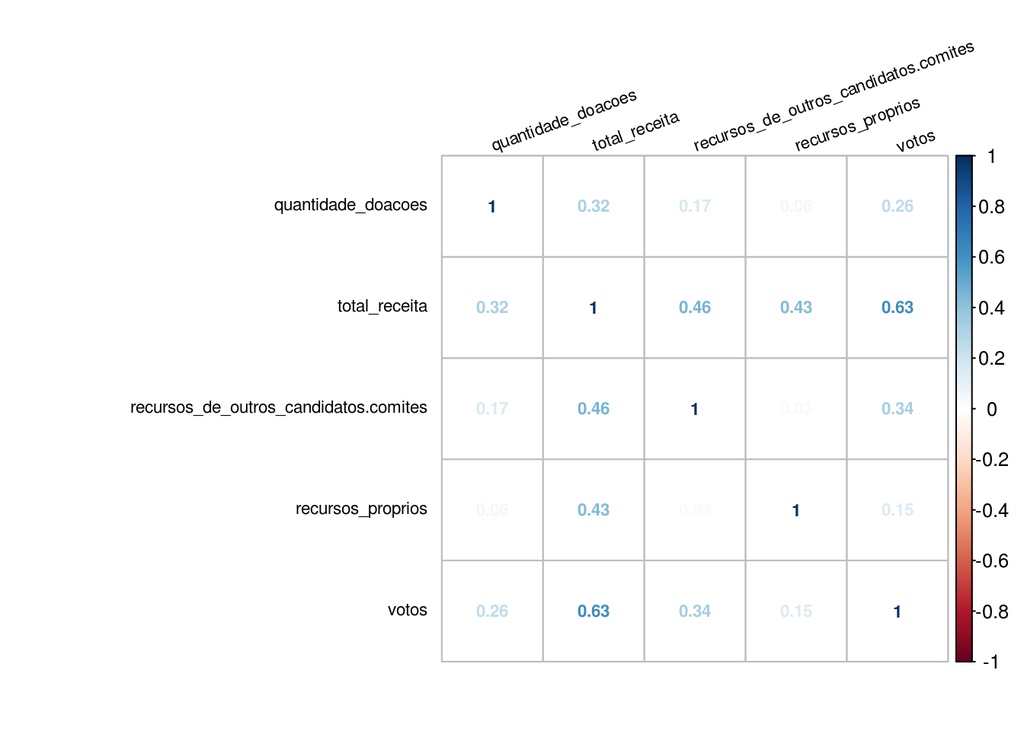

```r
dadosAjustados2010 <- dadosRegressao2010 %>%
  select(- quantidade_doadores, - recursos_de_pessoas_juridicas, - quantidade_despesas, -quantidade_fornecedores, - total_despesa, -recursos_de_partido_politico, - media_despesa, -media_receita, - recursos_de_pessoas_fisicas, recursos_de_outros_candidatos.comites) %>%
  select(-ano, -sequencial_candidato.dummy, -nome.dummy, -uf.dummy, -partido.dummy, -cargo.dummy, -sexo.dummy, -grau.dummy, -estado_civil.dummy, -ocupacao.dummmy)

dadosAjustados2010 %>%
  cor() %>%
  corrplot(
    method = "number",
    type = "full",
    tl.srt = 20,
    tl.col = "black",
    tl.cex = 0.7,
    tl.offset = 0.5,
    number.cex = 0.70,
    na.label = "NA"
  )
```

```r
modeloAjustado2010 <- lm(formula = votos ~ ., dadosAjustados2010, na.action = na.omit)

summary(modeloAjustado2010)
```

```
##
## Call:
## lm(formula = votos ~ ., data = dadosAjustados2010, na.action = na.omit)
##
## Residuals:
##     Min      1Q  Median      3Q     Max
## -214194   -8892   -8080   -3431 1302578
##
## Coefficients:
##                                         Estimate Std. Error t value
## (Intercept)                            8.997e+03  6.482e+02  13.881
## quantidade_doacoes                     1.641e+01  4.119e+00   3.984
## total_receita                          5.870e-02  1.456e-03  40.316
## recursos_de_outros_candidatos.comites  1.196e-02  4.986e-03   2.399
## recursos_proprios                     -3.440e-02  3.645e-03  -9.436
##                                       Pr(>|t|)
## (Intercept)                            < 2e-16 ***
## quantidade_doacoes                    6.89e-05 ***
## total_receita                          < 2e-16 ***
## recursos_de_outros_candidatos.comites   0.0165 *
## recursos_proprios                      < 2e-16 ***
## ---
## Signif. codes:  0 '***' 0.001 '**' 0.01 '*' 0.05 '.' 0.1 ' ' 1
##
## Residual standard error: 38030 on 4035 degrees of freedom
## Multiple R-squared:  0.4115, Adjusted R-squared:  0.411
## F-statistic: 705.5 on 4 and 4035 DF,  p-value: < 2.2e-16
```

Da mesma forma, conseguimos enxugar bastante o modelo, sem que hovesse uma perdar muito grande do quanto ele explica.

## Pergunta 5: Construa agora uma regressão considerando os anos 2006 e 2010 em conjunto. Que diferenças/semelhanças você percebe em relação aos modelos individuais por ano? Veja a questão 2 para sugestões que você usar para comparação.

```r
dados2006_2010$sequencial_candidato.dummy <- dummyfy(dados2006_2010$sequencial_candidato)
dados2006_2010$nome.dummy <- dummyfy(dados2006_2010$nome)
dados2006_2010$uf.dummy <- dummyfy(dados2006_2010$uf)
dados2006_2010$partido.dummy <- dummyfy(dados2006_2010$partido)
dados2006_2010$cargo.dummy <- dummyfy(dados2006_2010$cargo)
dados2006_2010$sexo.dummy <- dummyfy(dados2006_2010$sexo)
dados2006_2010$grau.dummy <- dummyfy(dados2006_2010$grau)
dados2006_2010$estado_civil.dummy <- dummyfy(dados2006_2010$estado_civil)
dados2006_2010$ocupacao.dummmy <- dummyfy(dados2006_2010$ocupacao)

dadosRegressao2006_2010 <-
  dados2006_2010 %>%
  select(-sequencial_candidato, -nome, -uf, -partido, -cargo, -sexo, -grau, -estado_civil, -ocupacao)

modeloCandidatos2006_2010 <- lm(formula = votos ~ ., dadosRegressao2006_2010, na.action = na.omit)

summary(modeloCandidatos2006_2010)
```

```
##
## Call:
## lm(formula = votos ~ ., data = dadosRegressao2006_2010, na.action = na.omit)
##
## Residuals:
##     Min      1Q  Median      3Q     Max
## -343137  -11153   -5714     643 1313965
##
## Coefficients: (2 not defined because of singularities)
##                                         Estimate Std. Error t value
## (Intercept)                            3.352e+06  7.269e+05   4.612
## ano                                   -1.664e+03  3.622e+02  -4.593
## quantidade_doacoes                    -7.919e+01  4.826e+01  -1.641
## quantidade_doadores                    1.334e+02  5.570e+01   2.395
## total_receita                         -4.009e-02  7.797e-03  -5.142
## media_receita                          1.118e-01  4.707e-02   2.375
## recursos_de_outros_candidatos.comites  1.602e-02  5.721e-03   2.800
## recursos_de_pessoas_fisicas            9.230e-02  8.493e-03  10.869
## recursos_de_pessoas_juridicas          3.627e-02  4.766e-03   7.610
## recursos_proprios                     -7.550e-03  4.552e-03  -1.659
## recursos_de_partido_politico                  NA         NA      NA
## quantidade_despesas                    1.453e+01  6.637e+00   2.189
## quantidade_fornecedores               -3.928e+01  8.273e+00  -4.748
## total_despesa                          9.725e-02  7.893e-03  12.321
## media_despesa                         -3.621e-02  8.415e-02  -0.430
## sequencial_candidato.dummy            -2.199e-01  4.107e-01  -0.535
## nome.dummy                            -3.756e-01  2.105e-01  -1.785
## uf.dummy                              -1.512e+02  5.814e+01  -2.601
## partido.dummy                         -1.284e+02  4.978e+01  -2.579
## cargo.dummy                                   NA         NA      NA
## sexo.dummy                             2.452e+03  1.229e+03   1.995
## grau.dummy                             1.252e+03  2.451e+02   5.107
## estado_civil.dummy                    -1.184e+03  3.366e+02  -3.518
## ocupacao.dummmy                       -4.473e+01  8.542e+00  -5.236
##                                       Pr(>|t|)
## (Intercept)                           4.06e-06 ***
## ano                                   4.44e-06 ***
## quantidade_doacoes                    0.100875
## quantidade_doadores                   0.016651 *
## total_receita                         2.79e-07 ***
```

[output cut: 10 more lines]

```
## sequencial_candidato.dummy            0.592401
## nome.dummy                            0.074358 .
## uf.dummy                              0.009301 **
## partido.dummy                         0.009915 **
## cargo.dummy                                 NA
## sexo.dummy                            0.046045 *
## grau.dummy                            3.36e-07 ***
## estado_civil.dummy                    0.000438 ***
## ocupacao.dummmy                       1.68e-07 ***
## ---
## Signif. codes:  0 '***' 0.001 '**' 0.01 '*' 0.05 '.' 0.1 ' ' 1
##
## Residual standard error: 36220 on 7454 degrees of freedom
## Multiple R-squared:  0.4258, Adjusted R-squared:  0.4241
## F-statistic: 263.2 on 21 and 7454 DF,  p-value: < 2.2e-16
```

Vemos que apesar de conter mais dados, o modelo utilizando dados de 2006 e 2010 consegue explicar menos dos votos do que o modelo considerando apenas 2006.